# Airline Satisfaction Project

```r
library(tidyverse)
library(tidymodels)
library(tidypredict)
library(readr)
library(dplyr)
library(rvest)
library(ggplot2)
library(forcats)
library(here)
library(kknn)
```

# Introduction

Since graduating from high school in 2015, I had many opportunities to travel the world and witness many different cultures throughout my volunteer and study abroad experience. Going somewhere far is inevitably expensive, especially when booking for flight routes. I used to spend so much time trying to get the best deals out of airline tickets by waiting at the right time of the day to save costs. Of course, many factors are usually involved when I decided to click the `purchase` button and therefore, I want to dive deep into these factors that influence my decision using data. As a usual airline traveler, this sparks my curiosity on how the Airline industry finds way to keep their customers Happy or at least satisified with the service. In this project, I will be looking at Airline Passenger Satisfaction Dataset provided by Maven Analytics and the goals is to answer some of the questions include:

1. Which percentage of airline passengers are satisfied? Does it vary by customer type? What about type of travel?
2. What is the customer profile for a repeating airline passenger?
3. Does flight distance affect customer perferences or flight patterns?
4. Which factors contribute to customer satisfaction the most? What about dissatifaction?

# Dataset:

A brief description for each variable:

- `ID`: Unique passenger identifier
- `Gender`: Gender of the passenger (Female/Male)
- `Age`: Age of the passenger
- `Customer Type`: Type of airline customer (First-time/Returning)
- `Type of Travel`: Purpose of the flight (Business/Personal)
- `Class`: Travel class in the airplane for the passenger seat
- `Flight Distance`: Flight distance in miles
- `Departure Delay`: Flight departure delay in minutes
- `Arrival Delay`: Flight arrival delay in minutes

Satification Level: from 1 lowest to 5 highest, 0 means “Not Applicable”

- `Departure and Arrival Time Convenience`: Satisfaction level with the convenience of the flight departure and arrival times
- `Ease of Online Booking`: Satisfaction level with the online booking experience
- `Check-in Service`: Satisfaction level with the check-in service
- `Online Boarding`: Satisfaction level with the online boarding experience
- `Gate Location`: Satisfaction level with the gate location in the airport
- `On-board Service`: Satisfaction level with the on-boarding service in the airport
- `Seat Comfort`: Satisfaction level with the comfort of the airplane seat
- `Leg Room Service`: Satisfaction level with the leg room of the airplane seat
- `Cleanliness`: Satisfaction level with the cleanliness of the airplane
- `Food and Drink`: Satisfaction level with the food and drinks on the airplane
- `In-flight Service`: Satisfaction level with the in-flight service
- `In-flight Wifi Service`: Satisfaction level with the in-flight Wifi service
- `In-flight Entertainment`: Satisfaction level with the in-flight entertainment
- `Baggage Handling`: Satisfaction level with the baggage handling from the airline
- `Satisfaction`: Overall satisfaction level with the airline (Satisfied/Neutral or unsatisfied)

# Exploratory Data Analysis

```r
airline <- read.csv("airline_passenger_satisfaction.csv")
```

```r
str(airline)
```

```
## 'data.frame':    129880 obs. of  24 variables:
##  $ ID                                    : int  1 2 3 4 5 6 7 8 9 10 ...
##  $ Gender                                : chr  "Male" "Female" "Male" "Male" ...
##  $ Age                                   : int  48 35 41 50 49 43 43 60 50 38 ...
##  $ Customer.Type                         : chr  "First-time" "Returning" "Returning" "Returning" ...
##  $ Type.of.Travel                        : chr  "Business" "Business" "Business" "Business" ...
##  $ Class                                 : chr  "Business" "Business" "Business" "Business" ...
##  $ Flight.Distance                       : int  821 821 853 1905 3470 3788 1963 853 2607 2822 ...
##  $ Departure.Delay                       : int  2 26 0 0 0 0 0 0 0 13 ...
##  $ Arrival.Delay                         : int  5 39 0 0 1 0 0 3 0 0 ...
##  $ Departure.and.Arrival.Time.Convenience: int  3 2 4 2 3 4 3 3 1 2 ...
##  $ Ease.of.Online.Booking                : int  3 2 4 2 3 4 3 4 1 5 ...
##  $ Check.in.Service                      : int  4 3 4 3 3 3 4 3 3 3 ...
##  $ Online.Boarding                       : int  3 5 5 4 5 5 4 4 2 5 ...
##  $ Gate.Location                         : int  3 2 4 2 3 4 3 4 1 2 ...
##  $ On.board.Service                      : int  3 5 3 5 3 4 5 3 4 5 ...
##  $ Seat.Comfort                          : int  5 4 5 5 4 4 5 4 3 4 ...
##  $ Leg.Room.Service                      : int  2 5 3 5 4 4 5 4 4 5 ...
##  $ Cleanliness                           : int  5 5 5 4 5 3 4 4 3 4 ...
##  $ Food.and.Drink                        : int  5 3 5 4 4 3 5 4 3 2 ...
##  $ In.flight.Service                     : int  5 5 3 5 3 4 5 3 4 5 ...
##  $ In.flight.Wifi.Service                : int  3 2 4 2 3 4 3 4 4 2 ...
##  $ In.flight.Entertainment               : int  5 5 3 5 3 4 5 3 4 5 ...
##  $ Baggage.Handling                      : int  5 5 3 5 3 4 5 3 4 5 ...
##  $ Satisfaction                          : chr  "Neutral or Dissatisfied" "Satisfied" "Satisfied" "Satisfied" ...
```

# Analysis 1:

### How many percentages of airline passengers are satisfied?

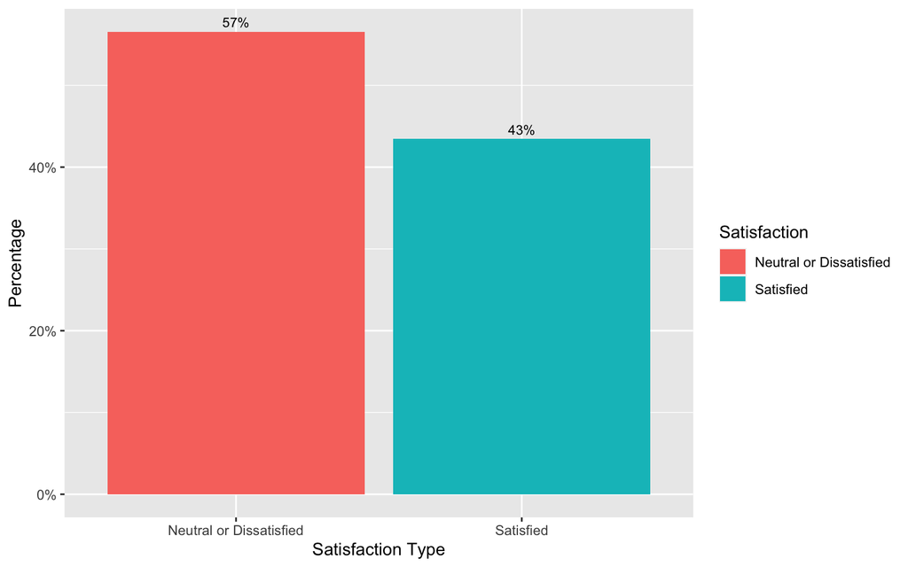

```r
airline %>%
  count(Satisfaction = factor(Satisfaction)) %>%
  mutate(pct = prop.table(n)) %>%
  ggplot(aes(x=Satisfaction, y = pct, fill = Satisfaction, label=scales::percent(pct))) +
  geom_col(position = 'dodge') +
  geom_text(position = position_dodge(width=.9), vjust = -0.5, size = 3) +
  scale_y_continuous(labels = scales::percent) +
  labs(x="Satisfaction Type", y = "Percentage")
```

Out of 120000+ passengers, only 43 percents of the passengers are satisfied overall. This statistics can be alarming since the overall satisfication rate stays below 50 percents.

### How many percentages of airline passengers are satisfied by Customer Type?

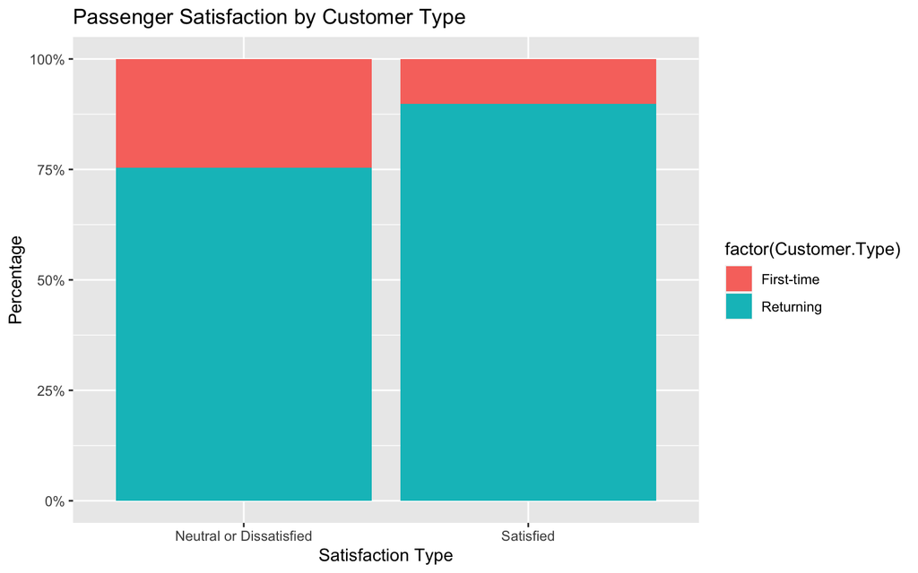

```r
airline %>%
  ggplot(aes(x=factor(Satisfaction), fill=factor(Customer.Type))) +
  geom_bar(position = "fill") +
  scale_y_continuous(labels = scales::percent) +
  labs(x="Satisfaction Type", y = "Percentage",
       title = "Passenger Satisfaction by Customer Type")
```

This bar plot demonstrates that majority of the airline customers are returning customers. They are accounted for the majority in both Satisfied and Nuetral/Satisfied level. What is important to see here is that about 75% of Nuetral/Satisfied customers are returning customers and they are the target groups if the airline wants to retain their current customers. **The next potential questions: What strategies should be implemented to reduce this percentage of unsatisfied returning customer to be satisfied with the services?**

### How many percentages of airline passengers are satisfied by Type of Travel?

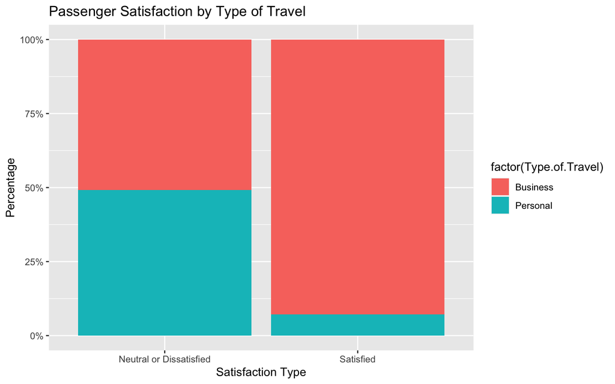

```r
airline %>%
  ggplot(aes(x=factor(Satisfaction), fill=factor(Type.of.Travel))) +
  geom_bar(position = "fill") +
  scale_y_continuous(labels = scales::percent) +
  labs(x="Satisfaction Type", y = "Percentage",
       title = "Passenger Satisfaction by Type of Travel")
```

As expected, around 90% of satified customers are those who travel for business purpose. It can be hypothesized that this number is high because business class tends to receive more premuim services. 50% of the unsatified customers are those who travel for personal purpose.

# Analysis 2:

### What the customer profile for a repeating airline passenger?

Many customers have chosen to travel again with the airline and I would like to know their demographics to understand our customer better. With the given data, I can observe the demographics from only `Gender` and `Age`. Note that repeating airline passengers are essentially returning passengers.

```r
airline %>%
  filter(Customer.Type == "Returning") %>%
  select(Gender) %>%
  count(Gender = factor(Gender)) %>%
  mutate(pct = n/sum(n))
```

```
##   Gender     n       pct
## 1 Female 53056 0.5000566
## 2   Male 53044 0.4999434
```

Gender ratio for the returning customers is about 1 to 1.

```r
airline %>%
  filter(Customer.Type == "Returning") %>%
  select(Age, Gender) %>%
  group_by(Gender) %>%
  summarise(mean = mean(Age), median = median(Age)) %>%
  as.data.frame()
```

```
##   Gender     mean median
## 1 Female 41.43705     43
## 2   Male 41.48697     43
```

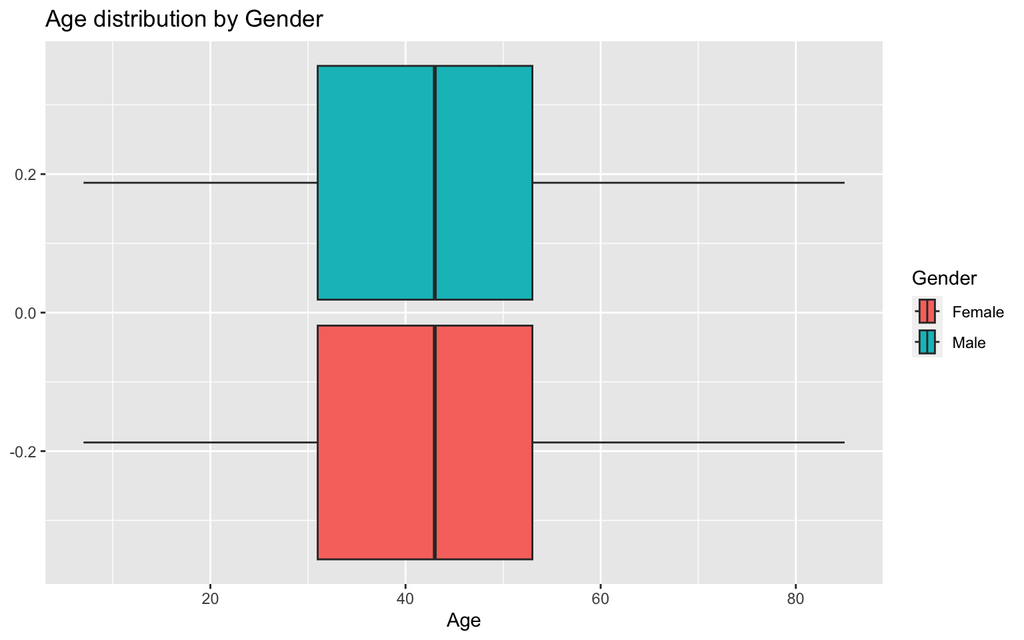

```r
airline %>%
  filter(Customer.Type == "Returning") %>%
  select(Age, Gender) %>%
  ggplot(aes(x=Age, fill = Gender)) +
  geom_boxplot() +
  labs(title = "Age distribution by Gender")
```

The median age for both male and female passengers are around 43 years while the average age is around 41 years old.

# Does flght distance affect customer perferences or flight patterns?

# Which factors contribute to customer satisfaction the most? What about dissatifaction?

In order to answer this question, we want to look at Regression

```r
airline.satisfied <-
  airline %>%
  filter(Satisfaction == "Satisfied")
```